# Discriminant analysis and classification

Romanova

26 ноября 2018 г

# 1 Информация о данных

Данные являются результатом химического анализа красных вин, выращенных в одном и том же регионе Италии, но полученных из трех разных сортов. Переменные – различные химические показатели.

1. Cultivar сорт винограда, качественный признак
   2. Alcohol процент содержания алкоголя
   3. Malic acid яблочная кислота
   4. Ash осадок
   5. Alcalinity of ash щелочность осадка
   6. Magnesium магний
   7. Total phenols общее содержание фенолов
   8. Flavanoids флаваноиды
   9. Nonflavanoid phenols нефлаваноидные фенолы
   10. Proanthocyanins проантоцианы
   11. Color intensity интенсивность цвета
   12. Hue оттенок
   13. OD280/OD315 of diluted wines показатель разведенности
   14. Proline пролин

количество индивидов в каждой группе:

1. 58
2. 68
3. 48

Всего индивидов: 174.

Максимально возможное количество канонических переменных: 2.

Первым делом рассмотрим matrx-plot, расскрашенный в соответствии с сортом винограда. Красным цветом отображается сорт barolo,зеленым – grignolino, синим – barbera.

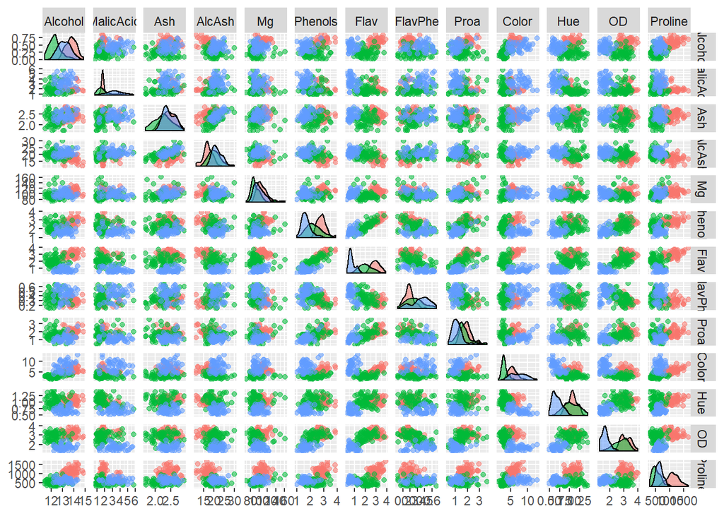

```r
ggpairs(wine.active,aes(colour = as.factor(wine.cultivar), alpha = 0.4), upper = list(continuous = "points", combo =
  "facethist", discrete = "facetbar", na = "na"))
```

Группы довольно ощутимо различаются, иногда по одному направленю, иногда по нескольким. Можно рассмотреть обрезанный matrix-plot, чтобы было лучше видно:

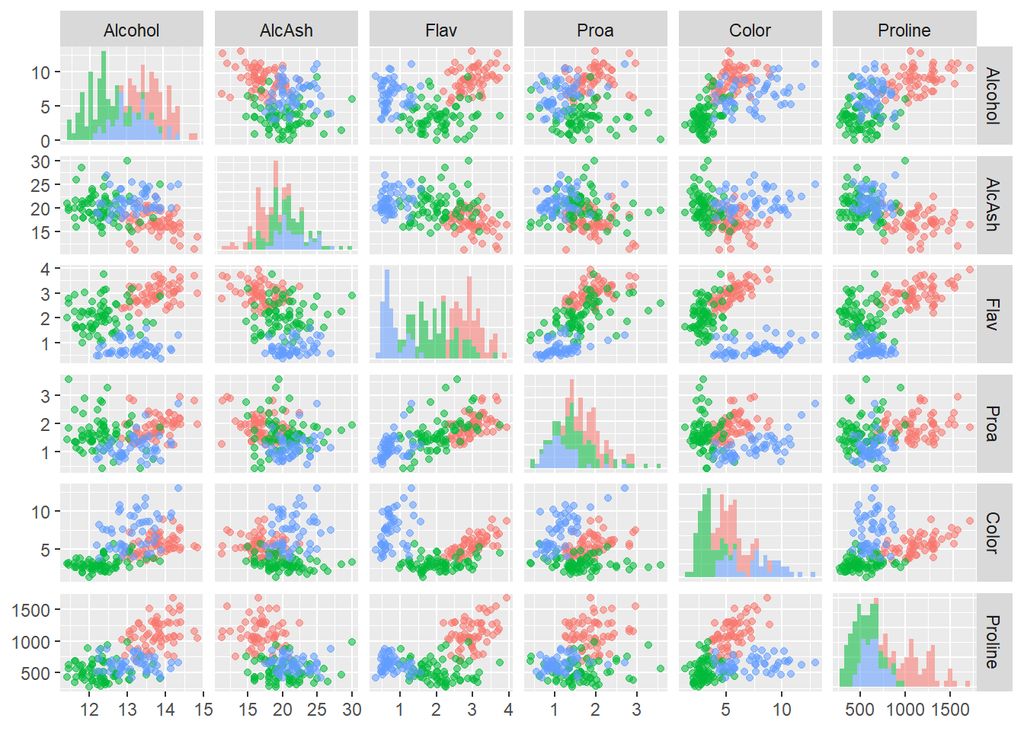

```r
ggpairs(wine.active[,c(1,4,7,9,10,13)],aes(colour = as.factor(wine.cultivar), alpha = 0.4), upper = list(continuous = "points", combo =
  "facethist", discrete = "facetbar", na = "na"),
  diag = list(continuous ="barDiag", discrete = "barDiag", na = "naDiag",binwidth = 0.4))
```

Различия между группами существенны, но группы довольно сильно пересекаются, что может быть не очень хорошо для последующей классификации.

# 2 Дискриминантный анализ

## 2.1 Соответствие модели

Для того, чтобы тесты значимости имели смысл, нужно, чтобы данные соответствовали модели, то есть, в данном случае, чтобы в каждой группе было нормальное распределение с одной и той же ковариационной матрицей. На самом деле, посмотрев на matrix-plot, мы не слишком надеемся на соответствие модели, по картинкам видно, что облака точек имеют разную форму по группам, что значит, что ковариационные матрицы различаются.

Гомоскедастичность. Проверяем гипотезу о том, что все ковариационные матрицы равны.

```r
wine.boxM<-boxM(wine.active,wine.cultivar)
wine.boxM
```

```
##
##  Box's M-test for Homogeneity of Covariance Matrices
##
## data:  wine.active
## Chi-Sq (approx.) = 638.19, df = 182, p-value < 2.2e-16
```

Никакой гомоскедастичности. Нормальность можно и не проверять, все равно нет соответствия модели (но если решим проверить: ее тоже совсем нет).

## 2.2 Значимость различий между группами

Перед тем, как проводить дискриминантный анализ и анализировать различия между группами, убедимся в том, что отличия между группами действительно есть (мы полагаем, что это так, изучив matrix-plot). Проверяем гипотезу о том, что средние в группах равны при помощи различных тестов.

```r
wine.manova<-manova(as.matrix(wine.active)~wine.cultivar)
summary(wine.manova,'Wilks')
```

```
##                Df    Wilks approx F num Df den Df    Pr(>F)
## wine.cultivar   2 0.016508   82.962     26    318 < 2.2e-16 ***
## Residuals     171
## ---
## Signif. codes:  0 '***' 0.001 '**' 0.01 '*' 0.05 '.' 0.1 ' ' 1
```

```r
summary(wine.manova,'Pillai')
```

```
##                Df Pillai approx F num Df den Df    Pr(>F)
## wine.cultivar   2 1.7248   77.133     26    320 < 2.2e-16 ***
## Residuals     171
## ---
## Signif. codes:  0 '***' 0.001 '**' 0.01 '*' 0.05 '.' 0.1 ' ' 1
```

```r
summary(wine.manova,'Hotelling-Lawley')
```

```
##                Df Hotelling-Lawley approx F num Df den Df    Pr(>F)
## wine.cultivar   2           14.672   89.158     26    316 < 2.2e-16 ***
## Residuals     171
## ---
## Signif. codes:  0 '***' 0.001 '**' 0.01 '*' 0.05 '.' 0.1 ' ' 1
```

```r
summary(wine.manova,'Roy')
```

```
##                Df    Roy approx F num Df den Df    Pr(>F)
## wine.cultivar   2 10.321   127.02     13    160 < 2.2e-16 ***
## Residuals     171
## ---
## Signif. codes:  0 '***' 0.001 '**' 0.01 '*' 0.05 '.' 0.1 ' ' 1
```

Все тесты явно отвергают гипотезу.

## 2.3 Hotelling test

Для того, чтобы понять, какие группы между собой различаются, можно использовать тест Хотелинга.

```r
print(hotelling.test(.~Cultivar, data = wine, pair = c(1,2)))
```

```
## Test stat:  58.543
## Numerator df:  13
## Denominator df:  112
## P-value:  0
```

```r
print(hotelling.test(.~Cultivar, data = wine, pair = c(2,3)))
```

```
## Test stat:  59.716
## Numerator df:  13
## Denominator df:  102
## P-value:  0
```

```r
print(hotelling.test(.~Cultivar, data = wine, pair = c(3,1)))
```

```
## Test stat:  206.27
## Numerator df:  13
## Denominator df:  92
## P-value:  0
```

Все группы между собой значимо различаются.

## 2.4 Расстояние Махаланобиса между группами

```r
pooled.cov<-wine.boxM$pooled
print(pairwise.mahalanobis(wine.active, cov = pooled.cov,grouping = wine.cultivar)$distance)
```

```
##          [,1]     [,2]    [,3]
## [1,]  0.00000 30.94911 67.1631
## [2,] 30.94911  0.00000 39.0604
## [3,] 67.16310 39.06040  0.0000
```

Все сорта сильно отличаются друг от друга. Наибольшее расстояние между сортами barolo и barbera.

## 2.5 Линейный дискриминантный анализ:

Для проведения линейного дискриминантного анализа будем использовать функцию candisc.

```r
wine.lm <- lm(cbind(Alcohol,MalicAcid, Ash,AlcAsh,Mg,Phenols,Flav,NonFlavPhenols,Proa,
                    Color,Hue,OD,Proline) ~ Cultivar, data=wine)
wine.can<- candisc(wine.lm, term = "Cultivar")
wine.can
```

```
##
## Canonical Discriminant Analysis for Cultivar:
##
##    CanRsq Eigenvalue Difference Percent Cumulative
## 1 0.91167     10.321     5.9696  70.344     70.344
## 2 0.81312      4.351     5.9696  29.656    100.000
##
## Test of H0: The canonical correlations in the
## current row and all that follow are zero
##
##   LR test stat approx F numDF denDF   Pr(> F)
## 1     0.016508   82.962    26   318 < 2.2e-16 ***
## 2     0.186881   58.013    12   160 < 2.2e-16 ***
## ---
## Signif. codes:  0 '***' 0.001 '**' 0.01 '*' 0.05 '.' 0.1 ' ' 1
```

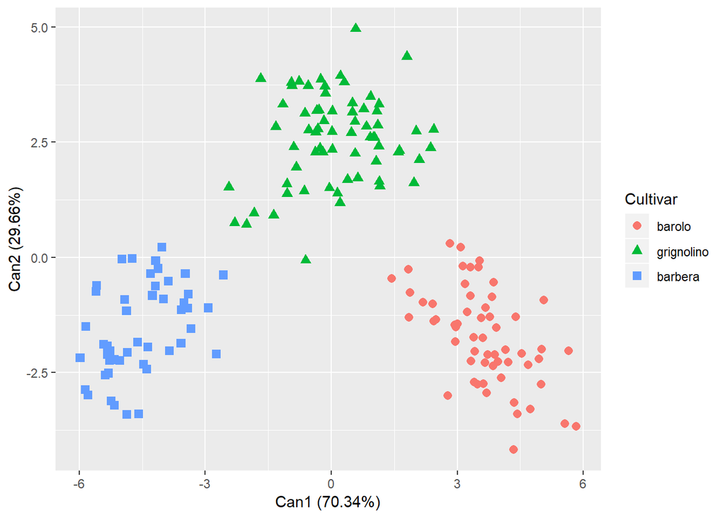

```r
dataset = data.frame(Cultivar = as.factor(wine[,"Cultivar"]),
                     wine.can = wine.can$scores)
ggplot(dataset) + geom_point(aes(wine.can$scores$Can1, wine.can$scores$Can2, colour = Cultivar, shape = Cultivar), size = 2.5) +
  labs(x = paste("Can1 (", round(wine.can$pct[1],2), "%)", sep=""),
       y = paste("Can2 (", round(wine.can$pct[2],2), "%)", sep=""))
```

Сразу видно, что вторая каноническая переменная тоже нужна. Первая переменная хорошо находит разницу между сортами “barolo” и “barbera”, а вторая – разницу между этими двумя и третим сортом.

Значимость канонических переменных проверяется при помощи теста Lambda-prime.

```r
print(wine.can)
```

```
##
## Canonical Discriminant Analysis for Cultivar:
##
##    CanRsq Eigenvalue Difference Percent Cumulative
## 1 0.91167     10.321     5.9696  70.344     70.344
## 2 0.81312      4.351     5.9696  29.656    100.000
##
## Test of H0: The canonical correlations in the
## current row and all that follow are zero
##
##   LR test stat approx F numDF denDF   Pr(> F)
## 1     0.016508   82.962    26   318 < 2.2e-16 ***
## 2     0.186881   58.013    12   160 < 2.2e-16 ***
## ---
## Signif. codes:  0 '***' 0.001 '**' 0.01 '*' 0.05 '.' 0.1 ' ' 1
```

Для обеих канонических переменных гипотеза о незначимости отвергается.

Теперь рассмотрим значения стандартизованных дискриминантных фунций и factor structure.

```r
wine.can$coeffs.std
```

```
##                       Can1         Can2
## Alcohol         0.13266124 -0.483972602
## MalicAcid      -0.13758361 -0.268112491
## Ash             0.09665758 -0.526334553
## AlcAsh         -0.34876199  0.414661791
## Mg              0.08997737  0.016082339
## Phenols        -0.42313434  0.008687307
## Flav            1.02874756  0.226598654
## NonFlavPhenols  0.26303835  0.220556554
## Proa           -0.13687948  0.184553126
## Color          -0.45301978 -0.345883748
## Hue             0.10327059  0.314519245
## OD              0.51252127 -0.009740158
## Proline         0.45173270 -0.515112632
```

```r
wine.can$structure
```

```
##                        Can1        Can2
## Alcohol         0.286475844 -0.80954440
## MalicAcid      -0.489570337 -0.30314229
## Ash            -0.002833565 -0.42574502
## AlcAsh         -0.568573015  0.23641171
## Mg              0.184474961 -0.33346752
## Phenols         0.754702494 -0.08320785
## Flav            0.923379106  0.01036380
## NonFlavPhenols -0.525603584  0.02210403
## Proa            0.535239268  0.05757061
## Color          -0.344055414 -0.76636407
## Hue             0.700846177  0.36502543
## OD              0.853640165  0.20002010
## Proline         0.615587294 -0.66508178
```

Интерпретировать канонические переменные удобно, используя следующий график:

```
## Vector scale factor set to 5.331
```

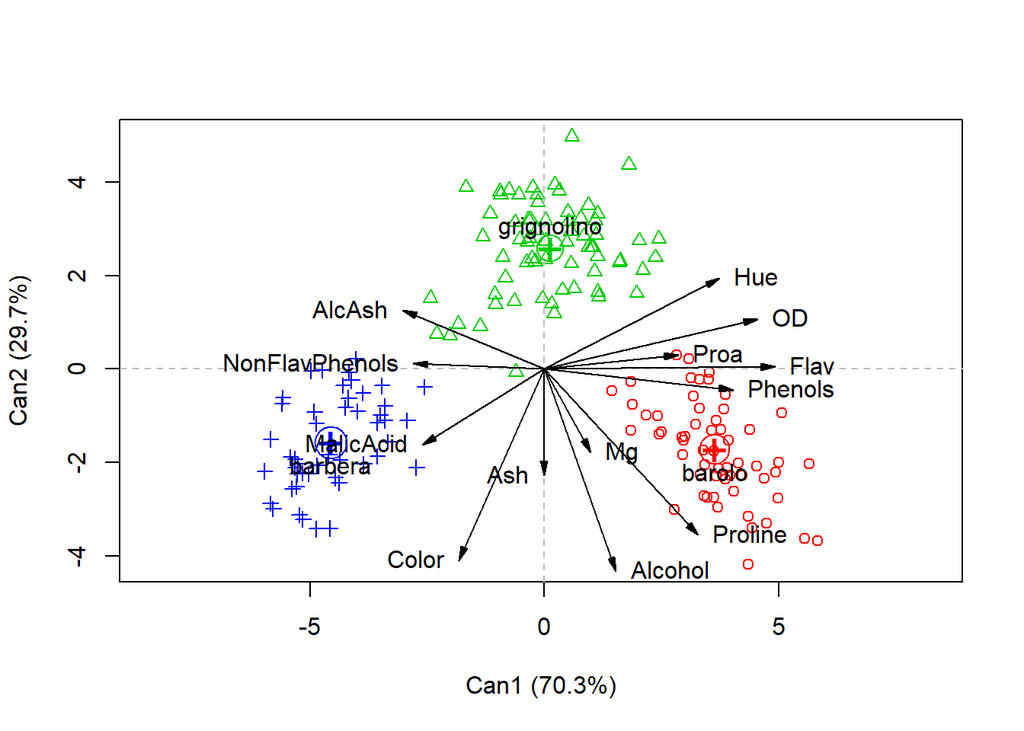

```r
plot(wine.can,col = c(2,3,4),var.col = "black")
```

Логично предположить, что вина должны различаться по качеству.

Немного дополнительной информации. Конечно, сложно оценивать стоимость вин по сорту винограда, так как она сильно варьируется в зависимости от многих факторов, но можно некоторые тенденции все же определить (для по крайней мере одного и того же региона). Так, вино из винограда gtignolino в среднем стоит 1000 рублей, barbera – в среднем 800, а цена на вино из винограда barolo в среднем составляет 6000 рублей (доходит и до 50000). Исходя из средней стоимости, возникает мысль, что те исходные переменные, которые направлены примерно в ту же сторону, что первая каноническая переменная – оказывают положительное влияние на вкусовые качества вина.

Возможно, первая каноническая переменная как раз и имеет смысл качества или вкуса? Чтобы ответить на этот вопрос, нужно немного разобраться в интерпретации исходных переменных и понять, как они могут влиять на качество вина (или на другие его понятные характеристики).

Переменные Flav (флавоноиды) и Phenols (общее содержание фенолов) практически сонаправлены с первой канонической компонентой. Именно полифенолы и, в частности, флавоноиды, дают вину способность предупреждать сердечно-сосудистую недостаточность (а также развитие рака, Альцгеймера и тд.) и в основном именно они отвечают за полезность. Яблочная кислота способствует пищеварению, но влияет на вкус, при увеличении доли кислоты он становится резким. Также ее больше в незрелом винограде. Пролин принимает активное участие при формировании полноты вкуса, также является одним из критериев натуральности вина.

Таким образом, первая каноническая переменная имеет смысл качества вина.

Тогда можно сказать, что сорт barolo имеет наивысшее качество, grignolino – среднее, а barbera – похуже. Этот вывод хорошо соотносится с нашими заметками о цене этих вин.

Вторая каноническая переменная описывает разницу между сортами barolo, barbera и сортом grignolino. Судя по картинке, вина из сорта grignolino имеют не очень яркий вкус и неинтенсивный цвет, а также значительно более низкое содержание алкоголя. По остальным показателям оно является средним. Видимо, вторая каноническая переменная имеет смысл, связанный конкретно с сортом grignolino и его спецификой. P.S.: вино из винограда grignolino называют самым белым среди красных.

Интерпретация в factor pattern и factor structure несколько отличается. Возможно, это связано с зависимостями в исходных данных.

## 2.6 Уменьшение числа признаков

Пошаговый дискриминантный анализ (пошаговое включение признаков).

```r
wine.forward<-greedy.wilks(Cultivar~.,data=wine, niveau = 0.01)
print(wine.forward)
```

```
## Formula containing included variables:
##
## Cultivar ~ Flav + Color + Proline + Alcohol + Hue + OD + AlcAsh +
##     Ash + Phenols
## <environment: 0x000000001b395e48>
##
##
## Values calculated in each step of the selection procedure:
##
##      vars Wilks.lambda F.statistics.overall p.value.overall
## 1    Flav   0.22260030             298.5965    1.634748e-56
## 2   Color   0.08549708             205.6988    1.993854e-89
## 3 Proline   0.04310023             215.0140   3.759796e-112
## 4 Alcohol   0.03369811             186.7950   9.322622e-119
## 5     Hue   0.02912621             162.3062   9.576189e-122
## 6      OD   0.02620302             143.2487   2.525791e-123
## 7  AlcAsh   0.02397393             128.6642   2.483992e-124
## 8     Ash   0.02038065             123.0968   5.823534e-128
## 9 Phenols   0.01917038             112.6955   5.085231e-128
##   F.statistics.diff p.value.diff
## 1        298.596521 1.634748e-56
## 2        136.306091 0.000000e+00
## 3         83.120984 0.000000e+00
## 4         23.436871 1.038823e-09
## 5         13.106884 5.134029e-06
## 6          9.259427 1.536112e-04
## 7          7.670819 6.511424e-04
## 8         14.457292 1.638934e-06
## 9          5.145268 6.803672e-03
```

Можем построить DA по тем переменным, которые советует оставить пошаговый DA.

```
## Vector scale factor set to 5.172
```

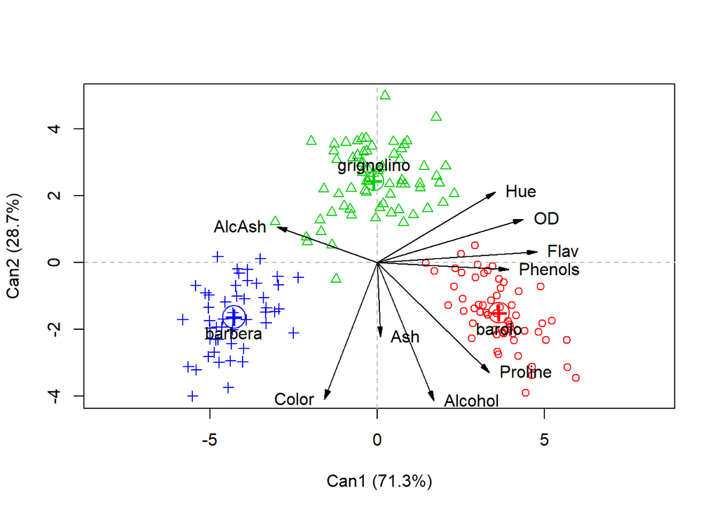

```r
wine.short.lm <- lm(cbind(Flav, Color,Proline,Alcohol,Hue,OD, AlcAsh, Ash,Phenols) ~ Cultivar, data=wine)

wine.short.can<- candisc(wine.short.lm, term = "Cultivar")
plot(wine.short.can,rev.axes=c(TRUE,FALSE),col = c(2,3,4),var.col = "black")
```

Ничего принципиально не изменилось.

# 3 Классификация

## 3.1 LDA

Таблица классификации:

```r
wine.train <-wine.active
wine.lda <-lda(wine.train, wine.cultivar)
wine.ldap<- predict(wine.lda, wine.train)$class
table( wine.cultivar,wine.ldap)
```

```
##              wine.ldap
## wine.cultivar barolo grignolino barbera
##    barolo         58          0       0
##    grignolino      0         68       0
##    barbera         0          0      48
```

Линейная классификация всю выборку (тренировочную) классифицирует правильно.

По кросс-валидации:

```r
wine.lda.cv <- lda(wine.train, wine.cultivar, CV = TRUE)
table(wine.cultivar,wine.lda.cv$class)
```

```
##
## wine.cultivar barolo grignolino barbera
##    barolo         58          0       0
##    grignolino      0         66       2
##    barbera         0          0      48
```

В просранстве первых двух канонческих переменных:

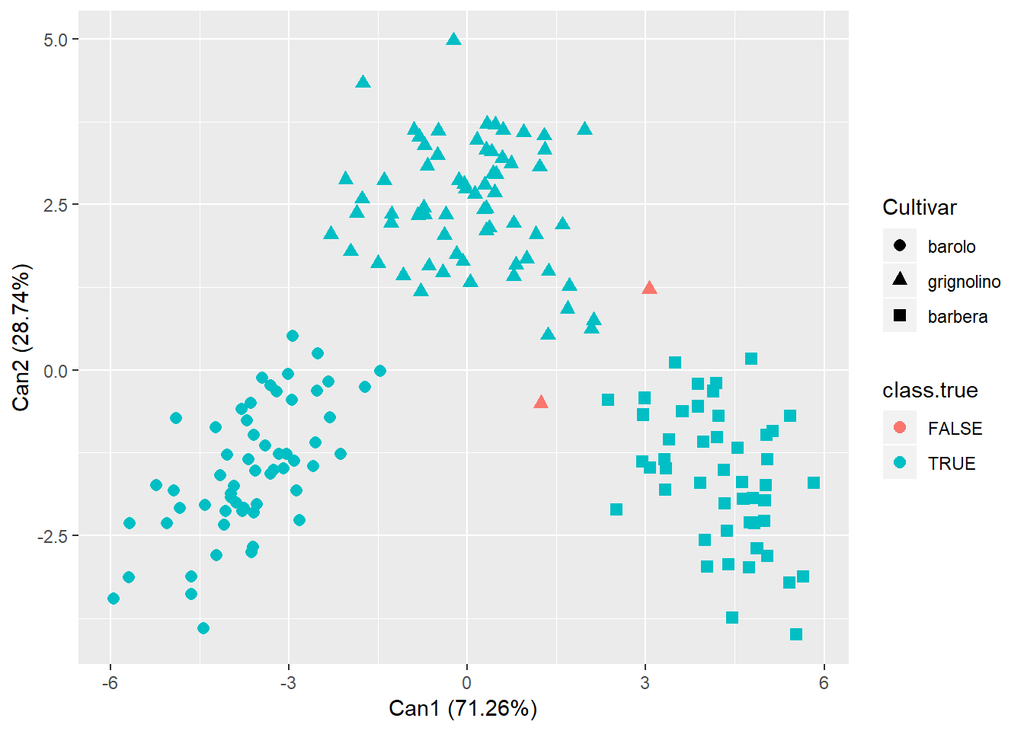

```r
class.true<-as.factor(wine.lda.cv$class ==wine.cultivar)
dataset = data.frame(Cultivar = as.factor(wine[,"Cultivar"]),
                     wine.short.can = wine.short.can$scores)
ggplot(dataset) + geom_point(aes(wine.short.can$scores$Can1, wine.short.can$scores$Can2, colour = class.true, shape = Cultivar), size = 2.5) +
  labs(x = paste("Can1 (", round(wine.short.can$pct[1],2), "%)", sep=""),
       y = paste("Can2 (", round(wine.short.can$pct[2],2), "%)", sep=""))
```

Два наблюдения классифицировано неправильно (были grignolino, стали barbera).

Посмотрим на апостериорные вероятности тех наблюдений, где были допущены ошибки:

```r
index<-which(wine.lda.cv$class !=wine.cultivar)
wine.lda.cv$posterior[index,]
```

```
##          barolo grignolino   barbera
## 62 9.042770e-11  0.2256225 0.7743775
## 69 3.551035e-04  0.1481509 0.8514940
```

Может быть, немного увеличить веса для сорта grignolino? Исходно априорные вероятности пропорциональны объему классов:

```r
wine.lda$prior
```

```
##     barolo grignolino    barbera
##  0.3333333  0.3908046  0.2758621
```

```r
wine.lda.cv<-lda(wine.train, wine.cultivar, CV = TRUE,prior=c(0.45,0.5,0.05))
table( wine.cultivar,wine.lda.cv$class)
```

```
##
## wine.cultivar barolo grignolino barbera
##    barolo         58          0       0
##    grignolino      0         68       0
##    barbera         0          0      48
```

но то, что мы сделали, вообще говоря, является подгонкой. Хотя веса остались в том же порядке, что и были (по размеру), не совсем выходит обосновать (помимо подгонки), почему мы сделали такой маленький вес для сорта barbera, так что далее эти веса использовать все же не будем.

Графики partimat удобнее смотреть в сравнении с результатами qda. (т.е. это будет ниже.)

## 3.2 QDA

Таблица классификации:

```r
wine.qda <-qda(wine.train, wine.cultivar)
wine.qdap<- predict(wine.qda, wine.train)$class
table(wine.cultivar,wine.qdap)
```

```
##              wine.qdap
## wine.cultivar barolo grignolino barbera
##    barolo         58          0       0
##    grignolino      0         68       0
##    barbera         0          0      48
```

Также, как и в случае lda, исходные данные классифицируются верно. По кросс-валидации:

```r
wine.qda <- qda(wine.train, wine.cultivar, CV = TRUE)
table( wine.cultivar,wine.qda$class)
```

```
##
## wine.cultivar barolo grignolino barbera
##    barolo         58          0       0
##    grignolino      0         68       0
##    barbera         0          1      47
```

Одно неправильно классифицированное наблюдение. То есть вроде как более хорошая обобщающая способность, чем у lda. Возможно, что этот вариант (qda) в данном случае действительно лучше, чем lda. Попробуем после проверить на тренировочной-тестовой выборках.

## 3.3 Сравнение результатов

Сравним формы классификации lda и qda.

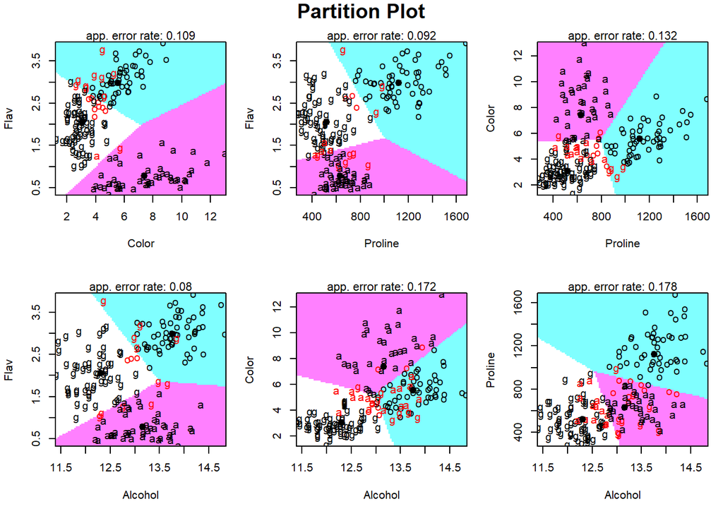

```r
partimat(Cultivar ~ Flav+Color+Proline+Alcohol, wine, method="lda",gs=c(rep("o",58),rep("g",68),rep("a",48)))
```

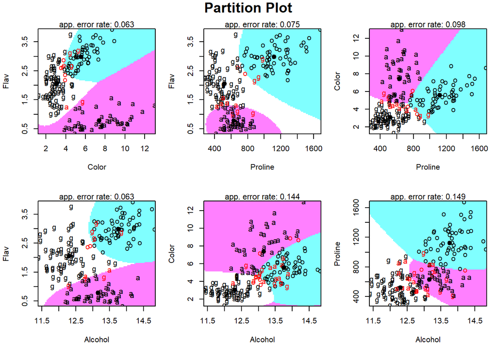

```r
partimat(Cultivar ~ Flav+Color+Proline+Alcohol, wine, method="qda",gs=c(rep("o",58),rep("g",68),rep("a",48)))
```

Можно заметить, что формы классифицирующих областей, в принципе, довольно похожи. На мой взгляд, qda больше похож на правду.

Сравним результаты на разных выборках.

LDA:

```r
wine.train <- wine[-seq(1,nrow(wine),3),]
wine.unknown<- wine[seq(1,nrow(wine),3),]
wine.lda <- lda(wine.train[,-1], wine.train[,1])
wine.ldap<- predict(wine.lda, wine.unknown[,-1])$class
table( wine.unknown[,1],wine.ldap)
```

```
##             wine.ldap
##              barolo grignolino barbera
##   barolo         20          0       0
##   grignolino      0         22       0
##   barbera         0          0      16
```

QDA не работает, если в некоторых группах мало наблюдений (должно быть больше (строго), чем переменных). Это еще одна причина, почему классификацию стоит проводить не по всем переменным, а по тем, которые остались, после удаления избыточных. Вообще, как показывают результаты при различном разбиении данных на тренировочную и тестовую выборку (а также интернет и здравый смысл), qda очень сильно зависит от объема тренировочной выборки. При малом объеме получается почти ерунда, так как параметров много, а наблюдений мало.

QDA:

```r
wine.qda <- qda(wine.train[,-1], wine.train[,1])
wine.qdap<- predict(wine.qda, wine.unknown[,-1])$class
table( wine.unknown[,1],wine.qdap)
```

```
##             wine.qdap
##              barolo grignolino barbera
##   barolo         20          0       0
##   grignolino      0         22       0
##   barbera         0          0      16
```

Окей, когда берем тренировочную выборку достаточно большого размера (относительно), то получается и там и там хорошо. (В данном случае мы 2/3 наблюдений отправили в тренировочную выборку и 1/3 в тестовую.)

Если наоборот:

```r
wine.train <- wine[seq(1,nrow(wine),3),]
wine.unknown<- wine[-seq(1,nrow(wine),3),]
wine.lda <- lda(wine.train[,-1], wine.train[,1])
wine.ldap<- predict(wine.lda, wine.unknown[,-1])$class
```

LDA:

```r
ct<-table( wine.unknown[,1],wine.ldap)
ct
```

```
##             wine.ldap
##              barolo grignolino barbera
##   barolo         38          0       0
##   grignolino      1         44       1
##   barbera         0          0      32
```

```r
prop.table(ct, 1)
```

```
##             wine.ldap
##                  barolo grignolino    barbera
##   barolo     1.00000000 0.00000000 0.00000000
##   grignolino 0.02173913 0.95652174 0.02173913
##   barbera    0.00000000 0.00000000 1.00000000
```

QDA:

```r
wine.qda <- qda(wine.train[,-1], wine.train[,1])
wine.qdap<- predict(wine.qda, wine.unknown[,-1])$class
ct<-table( wine.unknown[,1],wine.qdap)
ct
```

```
##             wine.qdap
##              barolo grignolino barbera
##   barolo         34          4       0
##   grignolino      0         46       0
##   barbera         0          1      31
```

```r
prop.table(ct, 1)
```

```
##             wine.qdap
##                 barolo grignolino   barbera
##   barolo     0.8947368  0.1052632 0.0000000
##   grignolino 0.0000000  1.0000000 0.0000000
##   barbera    0.0000000  0.0312500 0.9687500
```

С тренировочной выборкой такого размера у qda проблемы (у lda тоже, но поменьше).

# 4 ROC

Предположим, что мы решили потратиться и купить вино из винограда сорта barolo. Но мы не вполне уверены в честности продавца и боимся, что он подсунет нам менее качественное вино, выдав его за barolo.

Объединим классы grignolino и barbera.

```r
levels(wine$Cultivar)<-c("A","B","B")
zl <- lda(Cultivar ~ ., wine, prior = c(1,1)/2)
lda.pred<- predict(zl, wine)
zq<-qda(Cultivar ~ ., wine, prior = c(1,1)/2)
qda.pred<-predict(zq,wine)
pred.lda <- prediction(lda.pred$posterior[,2], wine$Cultivar)
pred.qda <- prediction(qda.pred$posterior[,2], wine$Cultivar)
perf <- performance(pred.lda, "tpr","fpr")
perfq <- performance(pred.qda, "tpr","fpr")
```

LDA:

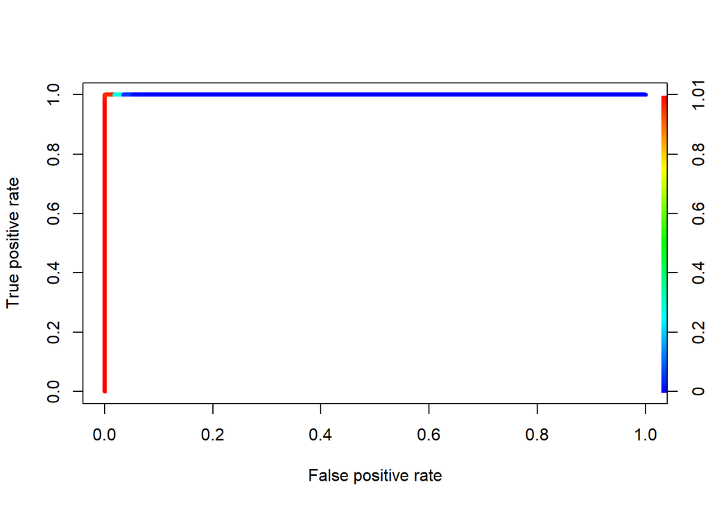

```r
plot(perf, colorize = TRUE,lwd=4)
```

QDA:

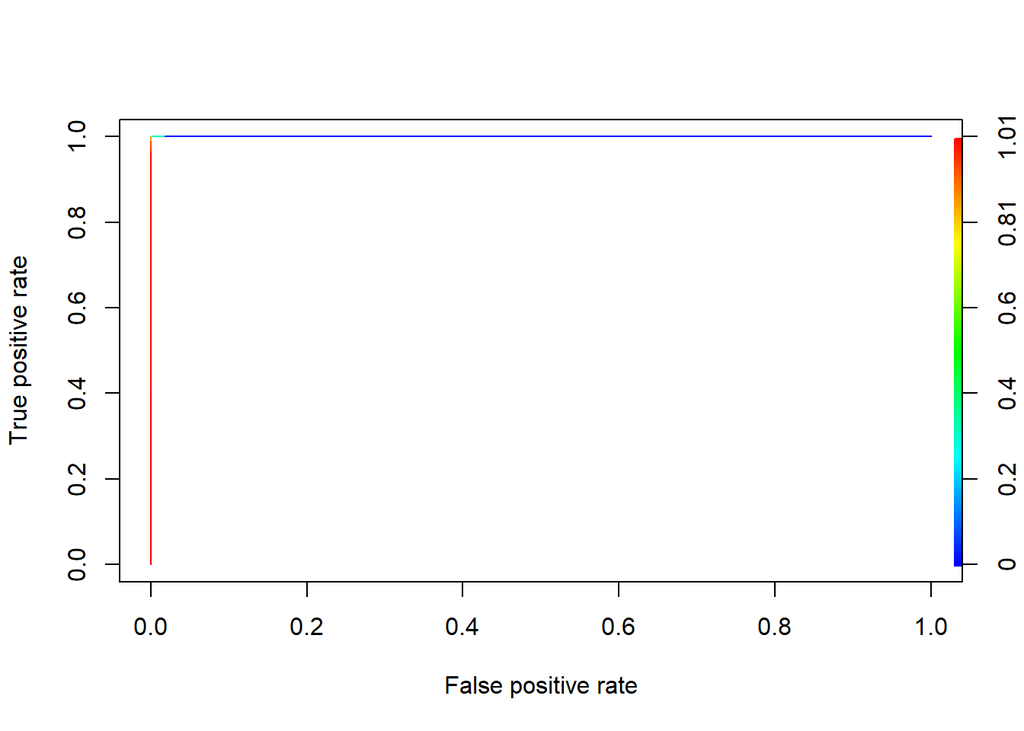

```r
plot(perfq,colorize=TRUE,add=FALSE)
```

К сожалению (или к счастью) у нас все совсем хорошо.

Если объединить другие два класса (barola и barbera):

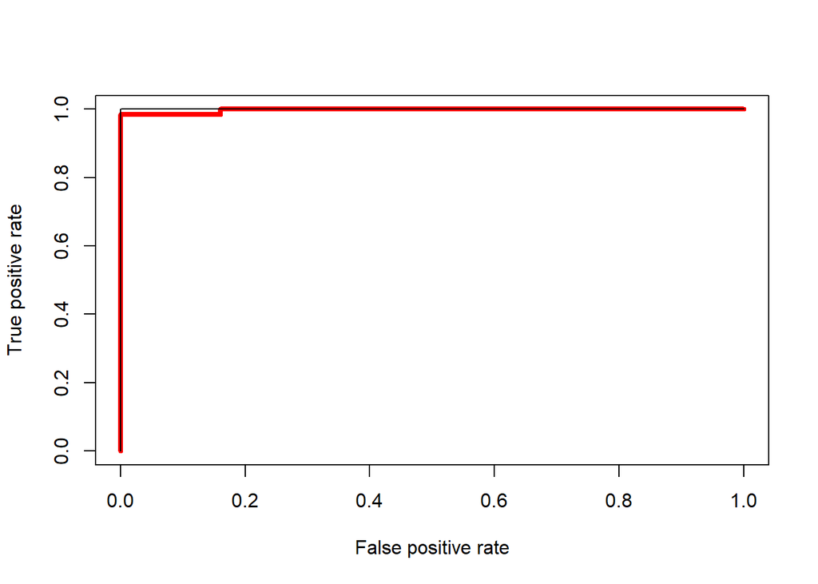

```r
levels(wine$Cultivar)<-c("A","B","A")
zl <- lda(Cultivar ~ ., wine, prior = c(1,1)/2)
lda.pred<- predict(zl, wine)
zq<-qda(Cultivar ~ ., wine, prior = c(1,1)/2)
qda.pred<-predict(zq,wine)
pred.lda <- prediction(lda.pred$posterior[,2], wine$Cultivar)
pred.qda <- prediction(qda.pred$posterior[,2], wine$Cultivar)
perf <- performance(pred.lda, "tpr","fpr")
perfq <- performance(pred.qda, "tpr","fpr")
plot(perf, col=2,lwd=4)
plot(perfq,col=1,add=TRUE,lwd=1)
```

Таким образом, для последнего разбиения на два класса модель qda лучше:

```r
AUC.ROCR.lda <- performance(pred.lda,"auc")
AUC.ROCR.qda <- performance(pred.qda,"auc")
print(AUC.ROCR.lda@y.values[[1]])
```

```
## [1] 0.9976415
```

```r
print(AUC.ROCR.qda@y.values[[1]])
```

```
## [1] 1
```

Посмотрим теперь на тренировочную-тестовую выборку.

```r
wine.train <- wine[-seq(1,nrow(wine),3),]
wine.unknown<- wine[seq(1,nrow(wine),3),]
```

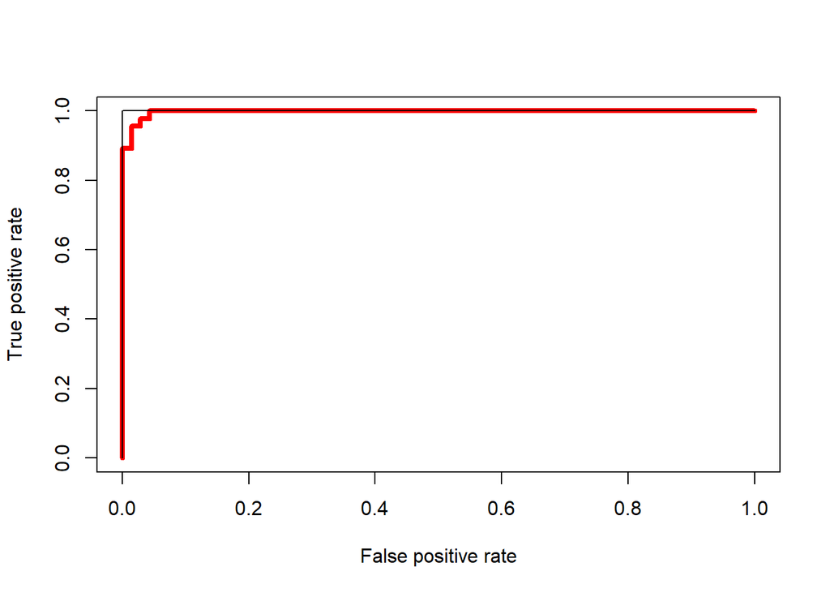

```r
levels(wine$Cultivar)<-c("A","B","A")

wine.train <- wine[seq(1,nrow(wine),3),]
wine.unknown<- wine[-seq(1,nrow(wine),3),]
zl <- lda(wine.train[,-1], wine.train[,1],prior = c(1,1)/2)
lda.pred<- predict(zl, wine.unknown[,-1])

zq<-qda(wine.train[,-1], wine.train[,1],prior = c(1,1)/2)
qda.pred<-predict(zq,wine.unknown[,-1])
pred.lda <- prediction(lda.pred$posterior[,2], wine.unknown$Cultivar)
pred.qda <- prediction(qda.pred$posterior[,2], wine.unknown$Cultivar)
perf <- performance(pred.lda, "tpr","fpr")
perfq <- performance(pred.qda, "tpr","fpr")
plot(perf, col=2,lwd=4)
plot(perfq,col=1,add=TRUE,lwd=1)
```

Снова qda лучше.

По кросс-валидации:

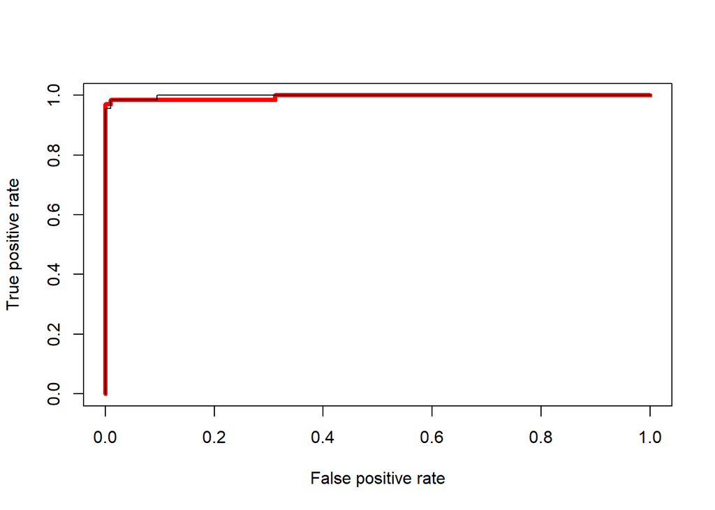

```r
zl <- lda(wine.active, wine$Cultivar,prior = c(1,1)/2, CV=TRUE)
zq<-qda(wine.active, wine$Cultivar,prior = c(1,1)/2,CV=TRUE)
pred.lda <- prediction(zl$posterior[,2], wine$Cultivar)
pred.qda <- prediction(zq$posterior[,2], wine$Cultivar)
perf <- performance(pred.lda, "tpr","fpr")
perfq <- performance(pred.qda, "tpr","fpr")
plot(perf, col=2,lwd=4)
plot(perfq,col=1,add=TRUE,lwd=1)
```

```r
AUC.ROCR.lda <- performance(pred.lda,"auc")
AUC.ROCR.qda <- performance(pred.qda,"auc")
print(AUC.ROCR.lda@y.values[[1]])
```

```
## [1] 0.995283
```

```r
print(AUC.ROCR.qda@y.values[[1]])
```

```
## [1] 0.9983352
```

Результат qda лучше, но не значительно.